# Activity2.1 - Titanic

# Titanic Wrangling

In this practice activity you’ll continue to work with the titanic dataset in ways that flex what you’ve learned about both data wrangling and data visualization.

```python
# Import the titanic dataset here

import numpy as np
import pandas as pd

data_dir = "https://dlsun.github.io/pods/data/"
df_titanic = pd.read_csv(data_dir + "titanic.csv")
```

## 1. Filter the data to include passengers only. Calculate the joint distribution (cross-tab) between a passenger’s class and where they embarked.

```python
# Code here
passenger_classes = ['1st', '2nd', '3rd']

df_passengers_only = df_titanic[df_titanic['class'].isin(passenger_classes)]

cross_tab_passengers_only = pd.crosstab(df_passengers_only['class'], df_passengers_only['embarked'])

cross_tab_passengers_only
```

| embarked class | B | C | Q | S |
| --- | --- | --- | --- | --- |
| 1st | 3 | 143 | 3 | 175 |
| 2nd | 6 | 26 | 7 | 245 |
| 3rd | 0 | 102 | 113 | 494 |

## 2. Using the joint distribution that calculated above, calculate the following:

- the conditional distribution of their class given where they embarked
- the conditional distribution of where they embarked given their class

Use the conditional distributions that you calculate to answer the following quesitons:

- What proportion of 3rd class passengers embarked at Southampton?
- What proportion of Southampton passengers were in 3rd class?

```python
# Part 1

# Class Given Where They Embarked
marginal_embarked_passengers = cross_tab_passengers_only.sum(axis=0)
conditional_class_given_embarked_passengers = cross_tab_passengers_only.divide(marginal_embarked_passengers, axis=1)

# Where They Embarked Given Their Class
marginal_class_passengers = cross_tab_passengers_only.sum(axis=1)
conditional_embarked_given_class_passengers = cross_tab_passengers_only.divide(marginal_class_passengers, axis=0)

conditional_class_given_embarked_passengers, conditional_embarked_given_class_passengers
```

```
(embarked         B         C         Q         S
 class
 1st       0.333333  0.527675  0.024390  0.191466
 2nd       0.666667  0.095941  0.056911  0.268053
 3rd       0.000000  0.376384  0.918699  0.540481,
 embarked         B         C         Q         S
 class
 1st       0.009259  0.441358  0.009259  0.540123
 2nd       0.021127  0.091549  0.024648  0.862676
 3rd       0.000000  0.143865  0.159379  0.696756)
```

The proportion of 3rd class passengers who embarked at Southampton is 0.696756 (or about 69.7%).

The proportion of Southampton passengers who were in the 3rd class is 0.540481 (or about 54.0%).

## 3. Make a visualization showing the distribution of a passenger’s class, given where they embarked.

Discuss the pros and cons of using this visualization versus the distributions you calculated before, to answer the previous questions.

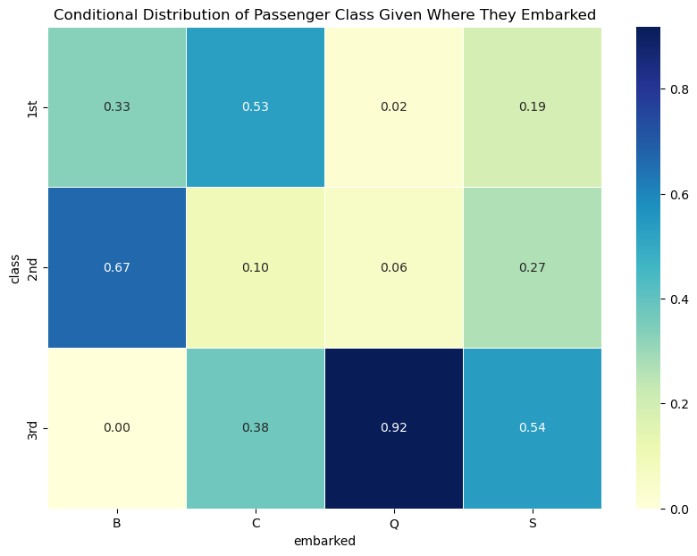

```python
import seaborn as sns
import matplotlib.pyplot as plt

# matplotlib figure
plt.figure(figsize=(10, 7))

# heatmap with the conditional distribution
sns.heatmap(conditional_class_given_embarked_passengers, annot=True, cmap="YlGnBu", fmt=".2f", linewidths=.5)

plt.title('Conditional Distribution of Passenger Class Given Where They Embarked')
plt.show()
```

While the conditional distributions provide precise numbers and answers, a heatmap offers a visual and intuitive understanding of the distribution. Both have their places, and their combined use can give both a detailed and holistic understanding of the data.